# *Análisis comparativo de los salarios de Data Science entre 2020-2023 a nivel internacional*

# 1 **Introducción**

En la actualidad, la ciencia de datos se ha convertido en una de las áreas más prometedoras y de mayor crecimiento en el mundo empresarial. Con la creciente demanda de profesionales altamente capacitados en esta disciplina, los salarios de los expertos en ciencia de datos también han aumentado significativamente. Por lo tanto, el análisis de los salarios en la industria de la ciencia de datos se ha convertido en una tarea crítica para entender la dinámica de esta disciplina y para tomar decisiones empresariales informadas.

## 1.1 Relevancia

Actualmente, Data Science es una carrera muy demandada en el país y en general, en el mundo. Podemos afirmar que es una carrera en gran crecimiento debido a las necesidades actuales a nivel nacional e internacional. De igual manera, Data Science es una carrera que garantiza un salario considerable a los expertos de dicha rama, esto como resultado de una gran demanda de profesionales en el sector.

Es así que consideramos importante realizar un análisis de cuánto puede llegar a ganar un experto en Data Science, teniendo en cuenta diversos factores, como su nivel de experiencia, el tipo de rol que ejerce, su país de residencia, entre otros tantos. De esta forma, podemos crear relaciones que expliquen correctamente los salarios que pueden lograr obtener los expertos en Ciencia de Datos.

## 1.2 Objetivos

### 1.2.1 Objetivo general

El objetivo general de este estudio estadístico es analizar los salarios en la industria de la ciencia de datos entre 2020-2023, con el fin de identificar patrones, tendencias y factores que influyen en los salarios de los profesionales de la ciencia de datos. El estudio también tiene como objetivo proporcionar información útil para las empresas y profesionales de la industria de la ciencia de datos, así como para investigadores y académicos interesados en el tema.

## 1.3 Contexto

Para entender de mejor forma el tema que vamos a analizar, ponemos en consideración que al tratarse de la carrera de Data Science, algunos términos podrían ser nuevos o quizá poco familiares para el lector. Básicamente son términos como el nivel de experiencia, el tipo de empleo, el rol en el trabajo, y la cantidad de trabajo remoto. Para ello, al inicio del análisis descriptivo de cada variable, se ha decidido realizar algunas precisiones, sobretodo en aquellas variables que podrían generar confusiones o dudas, para que el entendimiento del tema propuesto sea el mejor posible.

# 2 **Datos**

## 2.1 Recolección de datos

Para la recolección de datos, usamos la página KAGGLE para seleccionar un dataset sobre un tema en particular, que en esta ocasión trata sobre los salarios de Ciencia de Datos. Este tema fue del interés de todo el grupo luego de revisar las distintas opciones disponibles en el sitio web.

[Archivo de estudio en formato CSV](https://docs.google.com/spreadsheets/d/1qR07e2MtO135delNhWx-B-XJTj1yjeVmOzFIpe5Z9-0/edit?usp=sharing)

```r
library(readr)
data=read_csv("salarios_data_science.csv")
```

## 2.2 Población, muestra y muestreo

Teniendo en cuenta que nuestra base datos fue diseñada previamente, podemos detallar entonces:

### 2.2.1 Población

La **población** toma los registros de los salarios de empleados de Data Science desde 2020 hasta el 2023 a nivel internacional

```r
dim(data)
```

```
## [1] 3755   11
```

Las dimensiones de la población es de 3755 filas u observaciones y 11 columnas, que representan la cantidad de variables que manejamos

### 2.2.2 Unidad muestral

Empleados de Data Science desde 2020 hasta el 2023 a nivel internacional

### 2.2.3 Muestra

Hemos decidido sacar una muestra de 1000 de los salarios registrados en el dataset, de forma aleatoria.

```r
m <- data[sample(nrow(data), 1000), ]
```

Luego extraemos la muestra hacia un archivo CSV. Así evitamos una muestra que varíe en muchas ocasiones.

```r
library(readr)

muestra=read_csv("muestra.csv")
muestra
```

```
## # A tibble: 1,000 x 11
##    work_year experience_level employment_type job_title   salary salary_currency
##        <dbl> <chr>            <chr>           <chr>        <dbl> <chr>
##  1      2020 SE               FT              Data Engin~  42000 EUR
##  2      2023 SE               FT              Machine Le~ 126000 USD
##  3      2022 SE               FT              Applied Ma~ 108000 USD
##  4      2023 SE               FT              NLP Engine~ 175000 USD
##  5      2023 SE               FT              Data Engin~ 210000 USD
##  6      2023 EX               FT              Data Scien~ 145000 USD
##  7      2022 SE               FT              Data Scien~ 168000 USD
##  8      2020 EX               FT              Staff Data~  15000 USD
##  9      2022 SE               FT              Data Engin~ 250000 USD
## 10      2022 SE               FT              Data Analy~ 105000 USD
## # i 990 more rows
## # i 5 more variables: salary_in_usd <dbl>, employee_residence <chr>,
## #   remote_ratio <dbl>, company_location <chr>, company_size <chr>
```

Entonces, calculamos las dimensiones de la muestra que se extrajo finalmente:

```r
dim(muestra)
```

```
## [1] 1000   11
```

La función dim() me indica que la muestra presenta 1000 filas u observaciones y 11 columnas, que representan la cantidad de variables que manejamos.

### 2.2.4 Muestreo

De acuerdo a nuestro dataset y a la muestra que obtuvimos, podemos afirmar que utilizamos un muestreo aleatorio simple.

```r
nrow(muestra)
```

```
## [1] 1000
```

## 2.3 Variables

### 2.3.1 Presentación de variables

| Variables | Descripción | Tipo | Restricción |
| --- | --- | --- | --- |
| *work_year* | El año en que se pagó el salario. | Cualitativa ordinal | Entero no negativo |
| *experience_level* | El nivel de experiencia en el trabajo durante el año. | Cualitativa nominal | Cuatro valores (*EN*, *MI*, *SE*, *EX*) |
| *employment_type* | El tipo de empleo para el rol. | Cualitativa nominal | Cuatro valores (*PT*, *FT*, *CT*, *FL*) |
| *job_title* | Rol en el que se trabajó durante el año. | Cualitativa nominal | Valores referentes al rol del trabajo |
| *salary* | El monto total del salario bruto pagado. | Cuantitativa continua ordinal | Número entero o decimal no negativo |
| *salary_currency* | La moneda del salario pagado como un código de moneda ISO 4217. | Cualitativa nominal | Valores referentes a tipos de salarios |
| *salary_in_usd* | El salario en dólares americanos (USD). | Cuantitativa continua ordinal | Número entero o decimal no negativo |
| *employee_residence* | País de residencia principal del empleado durante el año laboral como código de país ISO 3166. | Cualitativa nominal | Valores referentes a países |
| *remote_ratio* | La cantidad total de trabajo realizado de forma remota. | Cualitativa ordinal | Tres valores, 0, 50 y 100 |
| *company_location* | El país de la oficina principal del empleador o sucursal contratante. | Cualitativa nominal | Valores referentes a países |
| *company_size* | La mediana del número de personas que trabajaron para la empresa durante el año (Tamaño de la empresa). | Cualitativa nominal | Tres valores (*S*,*M*,*L*) |

### 2.3.2 Análisis exploratorio

**Variable año**

```r
library(modeest)
mfv(muestra$work_year)
```

```
## [1] 2023
```

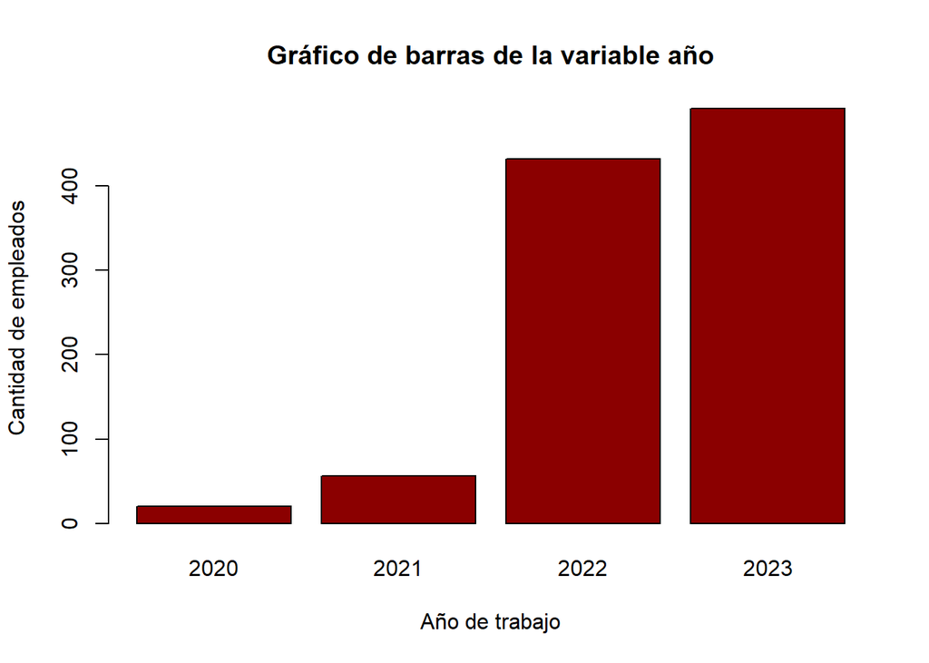

```r
barplot(table(muestra$work_year),main="Gráfico de barras de la variable año",col="darkred",xlab = "Año de trabajo",ylab = "Cantidad de empleados")
```

Del gráfico podemos inferir que a medida que transcurrieron los años del 2020 al 2023 se ha ido en aumento el número de empleados de Data Science por lo que podemos inferir que hubi un constante aumento en la demanda, del 2020 al 2021 la diferencia no es tan notoria, como lo es desde el 2021 al 2022, que se ve un indice alto de diferencia.

**Variable nivel de experiencia**

- EN, que se refiere a Entry-level/Junior.
- MI, que hace referencia a Nivel Medio/Intermedio.
- SE, que se refiere a Nivel Superior/Experto.
- EX, que hace referencia a nivel Ejecutivo/Director.

```r
library(modeest)
mfv(muestra$experience_level)
```

```
## [1] "SE"
```

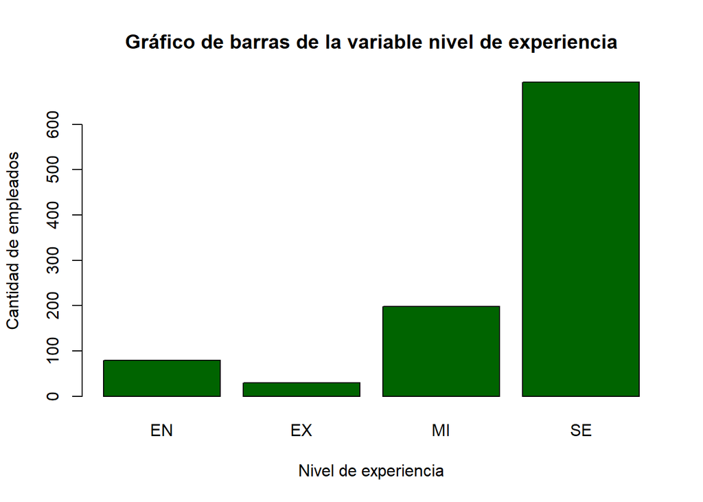

```r
barplot(table(muestra$experience_level),main="Gráfico de barras de la variable nivel de experiencia",col="darkgreen",xlab = "Nivel de experiencia",ylab = "Cantidad de empleados")
```

Del gráfico se infiere que la mayoría de los empleados tienen un nivel de experiencia Superior/Experto, seguido de el nivel de experiencia Medio Intermedio con un número mucho menor al Superior/ Experto, a ello le sigue el nivel Entry-level/Junior menor al nivel Medio Intermedio y por ultimo tenemos al Nivel Ejecutivo/Superio con un número muy bajo de empleados con ese nivel de experiencia.

**Variable tipo de empleo**

Hay 4 tipos de empleo aquí:

- PT - A tiempo parcial
- FT - Tiempo completo
- CT - Contrato
- FL - Independiente

```r
library(modeest)
mfv(muestra$employment_type)
```

```
## [1] "FT"
```

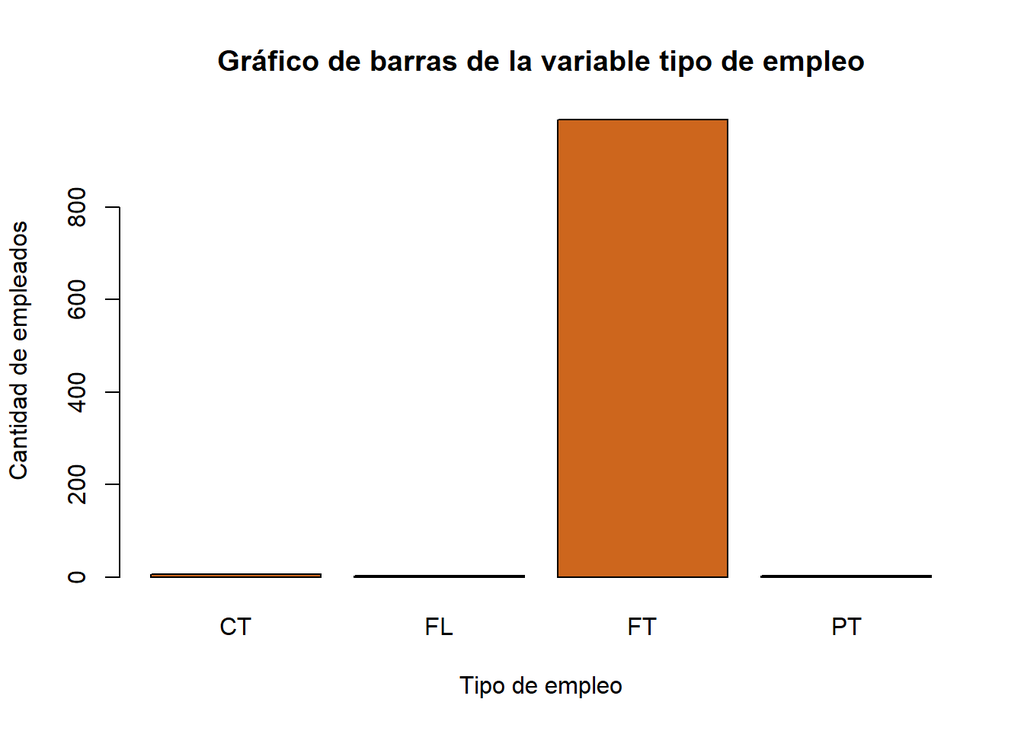

```r
barplot(table(muestra$employment_type),main="Gráfico de barras de la variable tipo de empleo",col="#CD661D",xlab = "Tipo de empleo",ylab = "Cantidad de empleados")
```

Del grafico se infiere que, todos o la mayoria de empleados trabajan a Tiempo Completo, y en consecuencia muy pocos trabajan A Tiempo Parcial, Contrato e Independiente.

**Variable rol de empleo**

```r
library(modeest)
mfv(muestra$job_title)
```

```
## [1] "Data Engineer"
```

```r
length(table(muestra$job_title))
```

```
## [1] 61
```

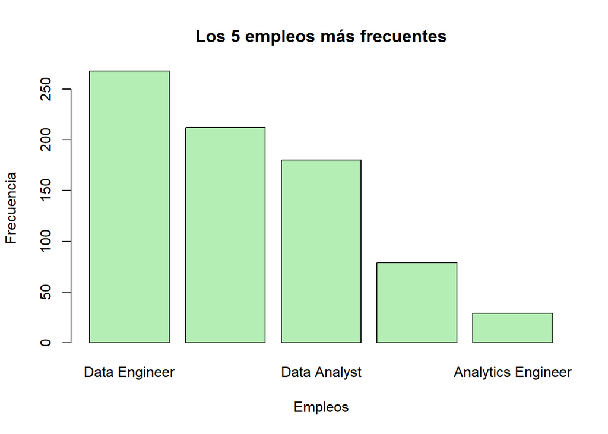

```r
frec <- table(muestra$job_title)
frec <- sort(frec, decreasing = TRUE)
top5frecuencias <- head(frec, 5)

barplot(top5frecuencias,
        main = "Los 5 empleos más frecuentes",
        xlab = "Empleos",
        ylab = "Frecuencia",
        col="#B4EEB4")
```

**Variable salario**

```r
library(modeest)
moda1<-mfv(muestra$salary)
m1<- format(moda1, scientific = F)
m1
```

```
## [1] "100000"
```

```r
tam1=length(table(muestra$salary)) #Cantidad de salarios distintos
tam1
```

```
## [1] 378
```

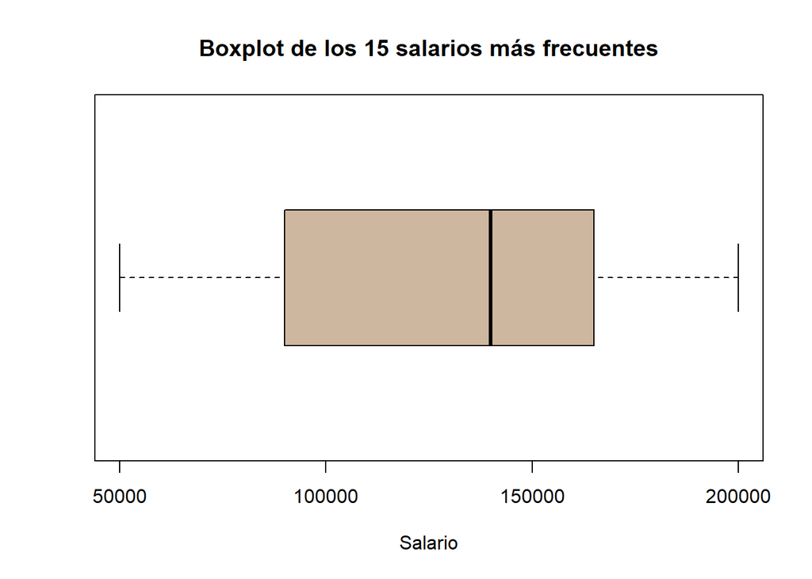

```r
salariosFrecuentes <- sort(table(muestra$salary), decreasing = TRUE)[1:15]

boxplot(as.numeric(names(salariosFrecuentes)),
        main = "Boxplot de los 15 salarios más frecuentes",
        horizontal = T,
        xlab = "Salario",
        col = "#CDB79E")
```

```r
max(muestra$salary) #Salario más alto
```

```
## [1] 30400000
```

```r
summary(muestra$salary)
```

```
##     Min.  1st Qu.   Median     Mean  3rd Qu.     Max.
##    12000   100000   139800   189437   180000 30400000
```